# The Reason Behind Trade Growth in China Compared to the United States

### James McNulty and Blake Marsh

The main question to answer in this project is the reasoning behind the difference in recent economic growth between the United States and China, specifically with regard to how trade has affected gross domestic product (GDP). The research goal is to identify the differences over the last century between the two countries that have caused China to become one of the economic powers that the world knows today.

This is an important question to answer because China’s growth has been very rapid, affecting the global economy and global prices. It is important to know the reasons behind why China’s growth has been so rapid and to identify possible places in the US that could be more efficient so the US can better compete with China. Some hypotheses on why China possibly could have had this rapid economic growth could be because of the reforms of Deng Xiaoping, which opened China up to trading with other nations through entering World Trade Organization (WTO). Another aspect that will be discussed is China's very low labor and manufacturing costs allowing them to export at low cost, which possibly could be supported by the use of child labor. This research shows the continually growing trade deficit that China has with the US, as China continues to export more to the US than the US is exporting to them. Through these questions, the project explains the reasoning as to why China has been growing at such a fast pace in the last two decades.

The several sources of information used include the World Bank, Trading Economics, and Statista to elaborate and explain why China has had such rapid growth along with showing the discrepancy between China's growth and the United States' growth. Specifically, the project looks at trade, labor, manufacturing, and policy differences. These aspects of each country's economy are used to show how China and the US's growth, trade, and (GDP) were impacted. Examples of what will be used within these categories are exports, industry value added, wages of the Chinese working class, and economic inequality. This allows us to identify why China is growing more rapidly with regards to trade than the United States, while also showing that the US is more advanced than China. These differences are portrayed in graphs, which will allow us to portray the overall differences and changes in each nation's growth with regards to trade.

The project uses a research paper format as it best fits the research findings.

The timeline for completion follows the class pace and due date. Over the next month, data will be gathered to analyze the findings and test the assumptions and accurately present the overall findings for the due date of November 13. Then, the findings will be compiled into analyses and a research paper so that the project can be presented on November 28.

```python
# Basic Packages
from __future__ import division
import os
from datetime import datetime

# Web & file access
import requests
import io

# Import display options for showing websites
from IPython.display import IFrame, HTML
```

```python
# Plotting
import matplotlib as mpl
import matplotlib.pyplot as plt
import matplotlib.ticker as mtick

%pylab --no-import-all
%matplotlib inline

import seaborn as sns
sns.set(rc={'figure.figsize':(11.7,8.27)})
sns.set_context("talk")

import plotly.express as px
import plotly.graph_objects as go

from plotnine import ggplot, geom_point, aes, stat_smooth, facet_wrap
# Next line can import all of plotnine, but may overwrite things? Better import each function/object you need
#from plotnine import *
```

```
Using matplotlib backend: <object object at 0x10b93e6b0>
%pylab is deprecated, use %matplotlib inline and import the required libraries.
```

```python
# Data
import pandas as pd
import numpy as np
from pandas_datareader import data, wb

# GIS & maps
import geopandas as gpd
gp = gpd
#import georasters as gr
#import geoplot as gplt
#import geoplot.crs as gcrs
#import mapclassify as mc
import textwrap
```

```python
# Data Munging
from itertools import product, combinations
import difflib
import pycountry
import geocoder
from geonamescache.mappers import country
mapper = country(from_key='name', to_key='iso3')
mapper2 = country(from_key='iso3', to_key='iso')
mapper3 = country(from_key='iso3', to_key='name')

# Regressions & Stats
from scipy.stats import norm
import statsmodels.formula.api as smf
from stargazer.stargazer import Stargazer, LineLocation
```

```python
# Paths
pathout = './data/'

if not os.path.exists(pathout):
    os.mkdir(pathout)

pathgraphs = './graphs/'
if not os.path.exists(pathgraphs):
    os.mkdir(pathgraphs)
```

```python
currentYear = datetime.now().year
year = min(2020, currentYear-2)
```

```python
url = 'https://pandas-datareader.readthedocs.io/en/latest/remote_data.html#remote-data-wb'
```

```python
wbcountries = wb.get_countries()
wbcountries = wbcountries.loc[wbcountries.region.isin(['Aggregates'])==False].reset_index(drop=True)
wbcountries['name'] = wbcountries.name.str.strip()
wbcountries['incomeLevel'] = wbcountries['incomeLevel'].str.title()
wbcountries.loc[wbcountries.iso3c=='VEN', 'incomeLevel'] = 'Upper Middle Income'
```

```python
wdi_indicators = ['NE.TRD.GNFS.ZS', 'NE.EXP.GNFS.CD', 'NY.GDP.MKTP.CD', 'NY.GDP.MKTP.KD.ZG']
```

```python
wdi = wb.download(indicator=wdi_indicators, country=['CHN', 'USA'], start=1930, end=year)
wdi = wdi.reset_index()
wdi['year'] = wdi.year.astype(int)
wdi['Trade_P_GDP'] = wdi['NE.TRD.GNFS.ZS']
wdi['Exports_of_GnS'] = wdi['NE.EXP.GNFS.CD']
wdi['GDP'] = wdi['NY.GDP.MKTP.CD']
wdi['GDP_Growth'] = wdi['NY.GDP.MKTP.KD.ZG']
wdi['Ln_Trade_P_GDP'] = wdi['NE.TRD.GNFS.ZS'].apply(np.log)
wdi['Ln_Exports_of_GnS'] = wdi['NE.EXP.GNFS.CD'].apply(np.log)
wdi['Ln_GDP'] = wdi['NY.GDP.MKTP.CD'].apply(np.log)
wdi['Ln_GDP_Growth'] = wdi['NY.GDP.MKTP.KD.ZG'].apply(np.log)
```

```python
wdichina = wb.download(indicator=wdi_indicators, country=['CHN'], start=1930, end=year)
wdichina = wdichina.reset_index()
wdichina['year'] = wdichina.year.astype(int)
wdichina['Trade_P_GDP'] = wdichina['NE.TRD.GNFS.ZS']
wdichina['Exports_of_GnS'] = wdichina['NE.EXP.GNFS.CD']
wdichina['GDP'] = wdichina['NY.GDP.MKTP.CD']
wdichina['GDP_Growth'] = wdichina['NY.GDP.MKTP.KD.ZG']
wdichina['Ln_Trade_P_GDP'] = wdichina['NE.TRD.GNFS.ZS'].apply(np.log)
wdichina['Ln_Exports_of_GnS'] = wdichina['NE.EXP.GNFS.CD'].apply(np.log)
wdichina['Ln_GDP'] = wdichina['NY.GDP.MKTP.CD'].apply(np.log)
wdichina['Ln_GDP_Growth'] = wdichina['NY.GDP.MKTP.KD.ZG'].apply(np.log)
```

```python
wdiusa = wb.download(indicator=wdi_indicators, country=['USA'], start=1930, end=year)
wdiusa = wdiusa.reset_index()
wdiusa['year'] = wdiusa.year.astype(int)
wdiusa['Trade_P_GDP'] = wdiusa['NE.TRD.GNFS.ZS']
wdiusa['Exports_of_GnS'] = wdiusa['NE.EXP.GNFS.CD']
wdiusa['GDP'] = wdiusa['NY.GDP.MKTP.CD']
wdiusa['GDP_Growth'] = wdiusa['NY.GDP.MKTP.KD.ZG']
wdiusa['Ln_Trade_P_GDP'] = wdiusa['NE.TRD.GNFS.ZS'].apply(np.log)
wdiusa['Ln_Exports_of_GnS'] = wdiusa['NE.EXP.GNFS.CD'].apply(np.log)
wdiusa['Ln_GDP'] = wdiusa['NY.GDP.MKTP.CD'].apply(np.log)
wdiusa['Ln_GDP_Growth'] = wdiusa['NY.GDP.MKTP.KD.ZG'].apply(np.log)
```

```python
wdi = wbcountries.merge(wdi, left_on='name', right_on='country')
wdi['Trade_P_GDP'] = wdi.Trade_P_GDP.astype(float)
```

```python
wdichina = wbcountries.merge(wdichina, left_on='name', right_on='country')
wdichina['Trade_P_GDP'] = wdichina.Trade_P_GDP.astype(float)
```

```python
wdiusa = wbcountries.merge(wdiusa, left_on='name', right_on='country')
wdiusa['Trade_P_GDP'] = wdiusa.Trade_P_GDP.astype(float)
```

```python
url = 'https://seaborn.pydata.org/examples/index.html'
```

```python
sns.set(rc={'figure.figsize':(11.7,8.27)})
sns.set_context("talk")

g1 = sns.relplot(x="year",
                y="GDP",
                data=wdi,
                hue="country",
                hue_order = wdi.country.drop_duplicates().sort_values(),
                style="country",
                style_order = wdi.country.drop_duplicates().sort_values(),
                size=400,
                sizes=(75, 400),
                alpha=.5,
                height=6,
                aspect=2,
                palette="bright",
               )
g1.set_axis_labels('Year', 'GDP')
```

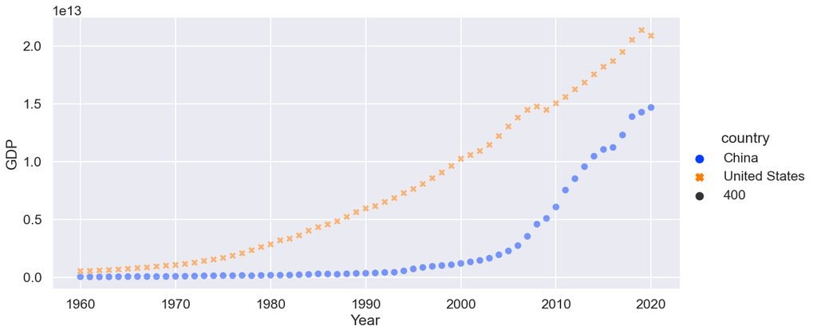

From this graph, The rapid growth of China's GDP starting from around 2005 until now is shown, while the United States has had very consistent increases since 1960, where the data starts.

```python
sns.set(rc={'figure.figsize':(11.7,8.27)})
sns.set_context("talk")

g2 = sns.relplot(x="year",
                y="GDP_Growth",
                data=wdi,
                hue="country",
                hue_order = wdi.country.drop_duplicates().sort_values(),
                style="country",
                style_order = wdi.country.drop_duplicates().sort_values(),
                size=400,
                sizes=(75, 400),
                alpha=.5,
                height=6,
                aspect=2,
                palette="bright",
               )
g2.set_axis_labels('Year', 'GDP Growth (%)')
```

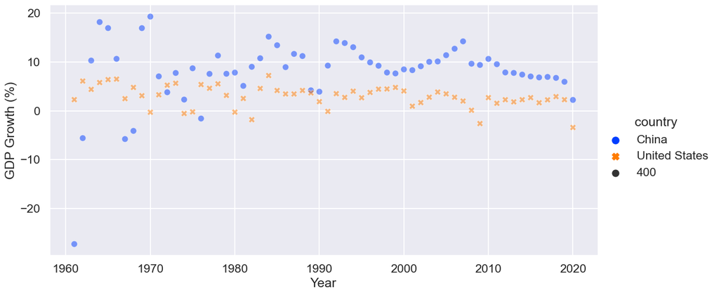

Looking at the graph which depicts the GDP growth as a percent, it is easy to see that China has been growing way faster than the United States for most of the years since where the data starts at 1961. Part of the reasoning behind this occurrence is because Deng Xiaoping opened up China to the world economy, which allowed China to trade more with other nations. This has had a massive effect on the industrialization of China and its growth into a world power. Another reason behind the large growth in China is due to the fact that China has been considered a developing country, whereas the United States has been established. The main reason for this is that countries that are established naturally do not have the same GDP growth as countries that are developing due to the law of diminishing returns, where the more growth a country has, the less it will ultimately grow. This is because countries that are growing have a long way to go before reaching a point where the return is 0 whereas a developed country is closer to that point of completely diminishing marginal returns.

```python
sns.set(rc={'figure.figsize':(11.7,8.27)})
sns.set_context("talk")

g = sns.relplot(x="year",
                y="Trade_P_GDP",
                data=wdi,
                hue="country",
                hue_order = wdi.country.drop_duplicates().sort_values(),
                style="country",
                style_order = wdi.country.drop_duplicates().sort_values(),
                size=400,
                sizes=(75, 400),
                alpha=.5,
                height=6,
                aspect=2,
                palette="bright",
               )
g.set_axis_labels('Year', 'Trade as a Percentage of GDP')
```

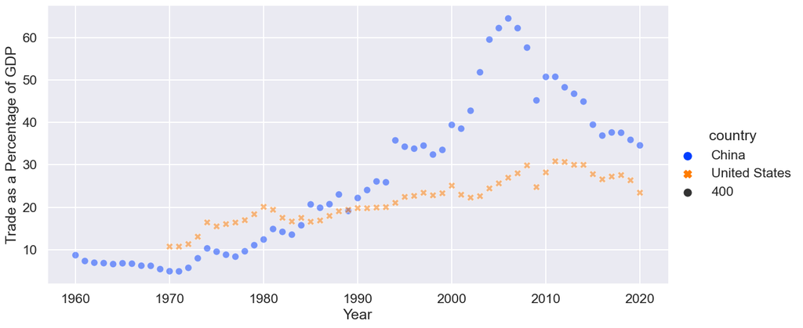

China's economic growth is due primarily to Deng Xiaoping's reforms which opened up the Chinese economy. The main reform that began the economic development of China was in 1978 when Xiaoping announced an Open Door Policy where there was now the ability for China to trade with other countries. Also, this policy allowed China to receive foreign investment, which led to the rapid economic growth. It is said that Xiaoping's main goal for China was to develop economically above all else. Xiaoping created what are called Special Economic Zones where there is a free-market structure rather than the original planned market. This free market allows supply and demand to function naturally rather than the very rigid and controlled structure of a planned economic structure where everything is based on the plans of the government. These Special Economic Zones allowed for foreign investment to rapidly increase in China due stark difference in regulations. Also, because foreign investment was something China had partaken in before 1978, the creation of these Special Economic Zones were appealing to foreign investors due to the fact that China was a developing country, meaning that their economic growth ceiling was a lot larger than that of a developed country like the United States.

The next major economic reform was when China joined the World Trade Organization (WTO) in 2001. As shown in the graph above, China's trade as a percentage of GDP jumped after the joining of the World Trade Organization, which allowed China to expand trade to other nations, furthering their economic development.

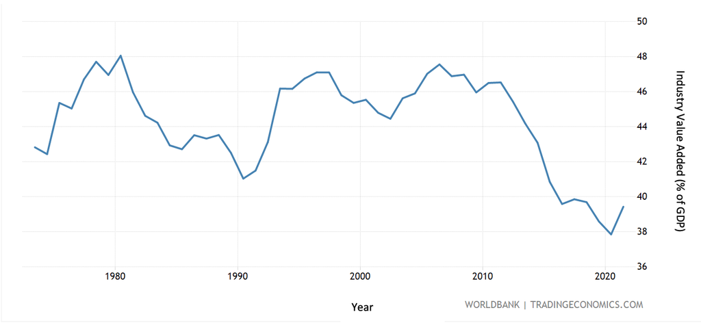

The graph above shows the Industry Value Added as a Percentage of GDP for China. The reason the data looks this way is due to the fact that China chose to manufacture certain products that would allow them to add the most possible value to the final good or service from the intermediate stage, which raises GDP. Unfortunately, a consequence of this was that the working conditions and wages of the Chinese workers were horrible.

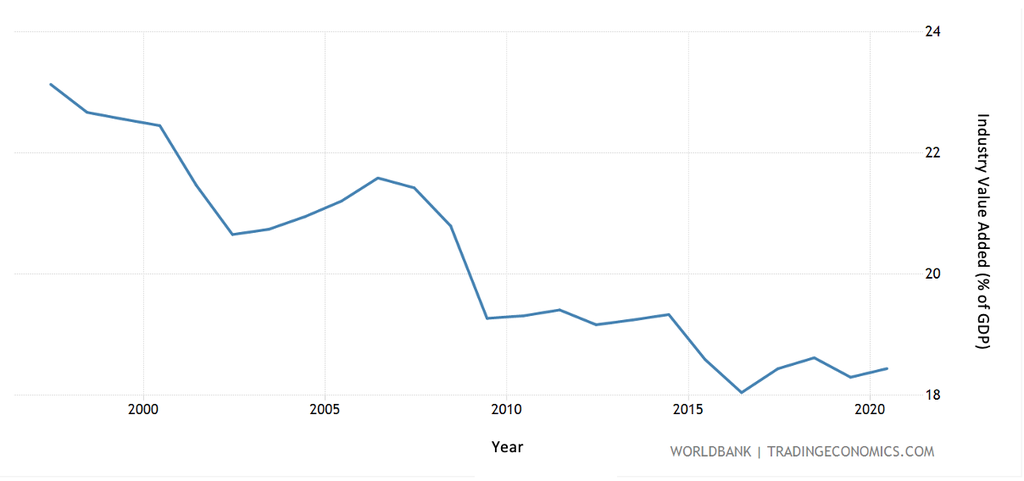

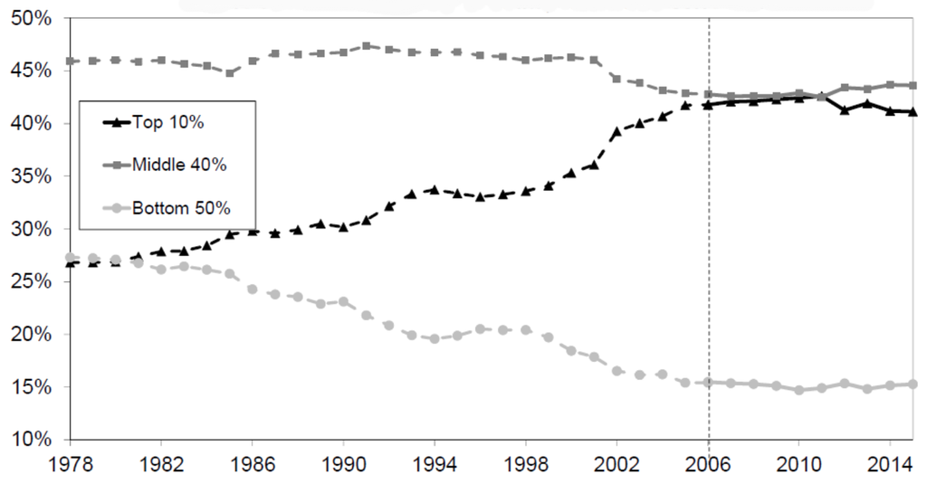

In this graph, there is a focus on income inequality from 1978 - 2015. The data shows the radical growth in income inequality over the past 37 years in China, proving that the working class is being unfairly paid. The bottom 50% of people in China earn roughly 15% of the total income, while the top 10% earn roughly 41% and the middle 40% earn 44%.

With regards to the two graphs above, it is safe to assume that because China has been focused on value-added rather than paying workers an appropriate wage, there is a natural effect of income inequality that arises since workers are making a minimum wage while the CEO's and other high-ranking people are taking the rest of that value added. It is estimated that the average Chinese worker makes 82,783 yuan per year, which seems like a lot in our minds, but 1 yuan is equivalent to 0.14 U.S. dollars, meaning that the average Chinese worker makes \$11,646.13 per year. This number has gone up over the last 10 years as well from 30,700 yuan, which is equivalent to \\$4318.96.

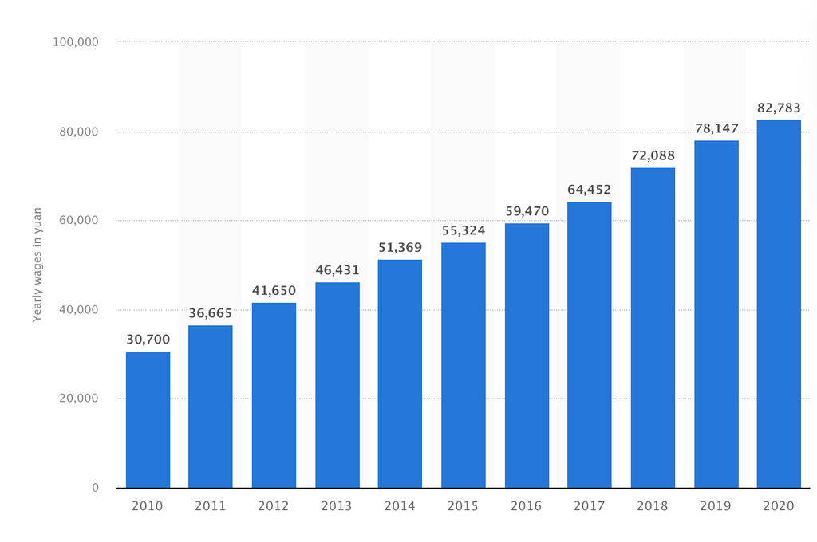

The graph above shows the average yearly wages in the manufacturing sector of China from the years 2010 to 2020, As of 2020 the average wages in China increased to 82,783 yuan. Which is 52,083 yuan more than what the average manufacturing wages were in 2010. This is a 169% increase in the average wage of every manufacturing worker which is significant growth further showcasing the rapid growth China has had.

It is also interesting to see the different in exports between the two countries. According to The Observatory of Economic Complexity (OEC), in 2020 the United States imported \$438 billion in goods and services from China while China imported \\$122 billion from the United States. The graph below also shows the difference in imports and exports since China joined the World Trade Organization on December 11, 2001.

[figure not shown]

With all of this information, it is clear that China's economic growth boom over the last 44 years in the trade sector has to do with the sector of exporting that they decided to enter into. The Chinese government chose a sector that allowed for rapid growth, but there has been an extreme consequence, that being the economic inequality of the Chinese working class as compared to the rest of the population. Not to mention child labor has also been prevalent in China as well. This growth has also been due to the fact that China is a developing country, meaning that their growth rate is further away from returns being diminished. This allows China to grow faster than the United States because the United States is considered developed, meaning that their growth rate is closer to that diminished margin. Overall, China's growth in the trade sector has to be credited in part to Deng Xiaoping's opening up of China and them entering into the World Trade Organization (WTO), which has led to the rapid development of China over the last 45 years.